# Your Capstone Project Title

### Assumption Check

> Prof. Roh’s Note: “Here, please check the linearity assumption, using *Global Validation of Linear Model Assumption* (`gvlma`) package. You may visualize the core infomation of assumption checks, using `ggfortify` package.”

```r
library(gvlma)
gvlma(model2)
```

```
##
## Call:
## lm(formula = swl ~ (fem + ageyear + educ + income) * sca + scb,
##     data = data2)
##
## Coefficients:
## (Intercept)          fem      ageyear         educ       income          sca
##    2.853239    -0.099341    -0.017982     0.087186     0.051227     0.037520
##         scb      fem:sca  ageyear:sca     educ:sca   income:sca
##    0.217028    -0.365823     0.005126    -0.096751     0.037190
##
##
## ASSESSMENT OF THE LINEAR MODEL ASSUMPTIONS
## USING THE GLOBAL TEST ON 4 DEGREES-OF-FREEDOM:
## Level of Significance =  0.05
##
## Call:
##  gvlma(x = model2)
##
##                      Value p-value                Decision
## Global Stat        4.11747  0.3903 Assumptions acceptable.
## Skewness           0.01813  0.8929 Assumptions acceptable.
## Kurtosis           1.54813  0.2134 Assumptions acceptable.
## Link Function      2.01474  0.1558 Assumptions acceptable.
## Heteroscedasticity 0.53647  0.4639 Assumptions acceptable.
```

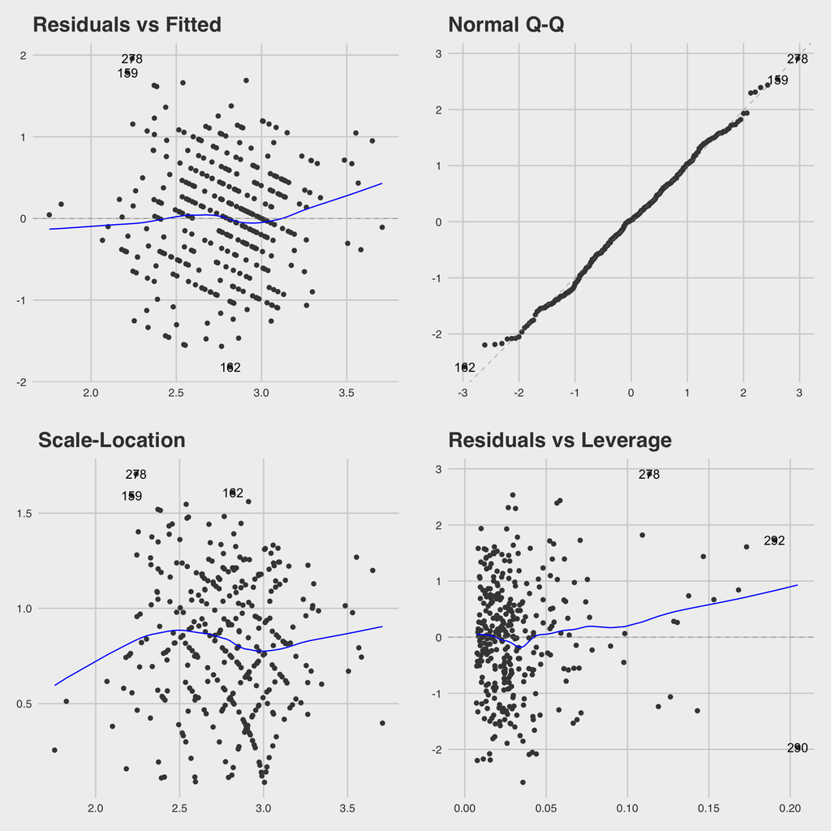

```r
library(ggthemes)
theme_set(theme_fivethirtyeight())

library(ggfortify)
autoplot(gvlma(model2))
```

### Check Multicollinearity

```r
library(car)
vif(model1);vif(model2)
```

```
##      fem  ageyear     educ   income      sca      scb
## 1.148087 1.440421 1.337597 1.016850 1.796158 1.747823
```

```
##         fem     ageyear        educ      income         sca         scb
##    1.167083    1.470039    1.343337    1.030797    3.384099    1.768687
##     fem:sca ageyear:sca    educ:sca  income:sca
##    2.594742    1.519403    1.447369    1.060966
```

### Report the Results with `kable` in `R Markdown`

> Prof. Roh’s Note: “Now that the assumption check is done, you might want to put the results into a prettier format of table. The default print-out of table in `R Markdown` does not look good. The `knitr` package contains a very basic command, `kable`, which will format an array or data frame more presentable for display. Thus, use the following for your report.”

```r
library(knitr) # Please install the package "knitr" first.
library(kableExtra) # You might want to use package "kableExtra" as well.
kable(tidy(model2))%>%
  kable_styling("striped", full_width = T, fixed_thead = T) %>%
  column_spec(c(1, 5), bold = T) %>%
  row_spec(c(2, 4, 6, 8, 10), bold = T, color = "white", background = "#ff6347")
```

| term | estimate | std.error | statistic | p.value |
| --- | --- | --- | --- | --- |
| (Intercept) | 2.8532389 | 0.0602889 | 47.3260685 | 0.0000000 |
| fem | -0.0993405 | 0.0850630 | -1.1678459 | 0.2437383 |
| ageyear | -0.0179818 | 0.0037463 | -4.7999010 | 0.0000024 |
| educ | 0.0871861 | 0.0363440 | 2.3989108 | 0.0170158 |
| income | 0.0512266 | 0.0180170 | 2.8432324 | 0.0047530 |
| sca | 0.0375196 | 0.0982741 | 0.3817853 | 0.7028740 |
| scb | 0.2170284 | 0.0769805 | 2.8192660 | 0.0051133 |
| fem:sca | -0.3658230 | 0.1140477 | -3.2076331 | 0.0014737 |
| ageyear:sca | 0.0051264 | 0.0055671 | 0.9208321 | 0.3578318 |
| educ:sca | -0.0967507 | 0.0477145 | -2.0277013 | 0.0434191 |
| income:sca | 0.0371898 | 0.0251264 | 1.4801076 | 0.1398284 |

```r
kable(glance(model2))%>%
  kable_styling("striped", full_width = T, font_size = 12) %>%
  column_spec(c(2, 4, 6, 8, 10, 12), bold = T, color = "white", background = "#ff6347")
```

| r.squared | adj.r.squared | sigma | statistic | p.value | df | logLik | AIC | BIC | deviance | df.residual | nobs |
| --- | --- | --- | --- | --- | --- | --- | --- | --- | --- | --- | --- |
| 0.1584358 | 0.1321369 | 0.7150843 | 6.02443 | 0 | 10 | -353.0728 | 730.1455 | 775.7709 | 163.6306 | 320 | 331 |

The regression analysis came up with two significant interaction terms.

- First, it appears that the relationships between social comparisons orientation regarding abilities and life satisfaction is different depending on one’s **gender**.
- Second, it appears that the relationships between social comparisons orientation regarding abilities and life satisfaction is different depending on one’s **education**.

To see the patterns of interaction, we visualized the significant interaction effects on the next chapter.

## Visualize

### Part 1: Social Comparison X Gender

To visualize the OLS regression analysis performed above, we stored the OLS regression model’s predictions.

```r
grid <- data2 %>%
  data_grid(sca, fem, ageyear = 0, educ = 0, income = 0, scb = 0) %>%
  add_predictions(model2)
```

We undid the centering of variable (`sca`).

```r
grid <- grid %>%
  mutate(sca = sca + mean(data$sca))
```

The following figure represents the two lines that represent differing genders, and how each gender differs in its relationships between social comparison orientation and life satisfaction.

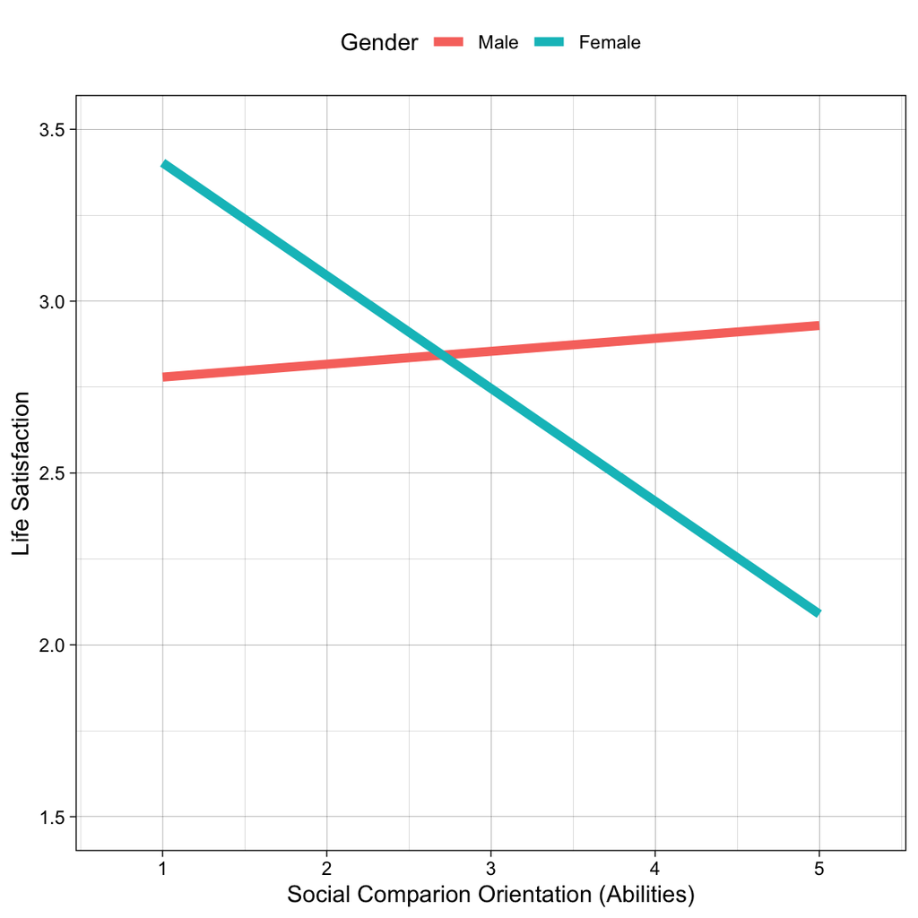

```r
ggplot(grid, aes(x = sca, y = pred, color = factor(fem))) +
  geom_line(size = 2)+
  scale_color_discrete(breaks = c(0, 1), label=c("Male", "Female")) +
  labs(x="Social Comparion Orientation (Abilities)",
       y="Life Satisfaction",
       color="Gender")+
  coord_cartesian(ylim=c(1.5, 3.5), xlim=c(0.7, 5.3))+
  theme_linedraw() +
  theme(legend.position = "top")
```

We also plotted the two genders separately, along with data points represented with dots, so that we could see the patterns of the relationship from a different angle.

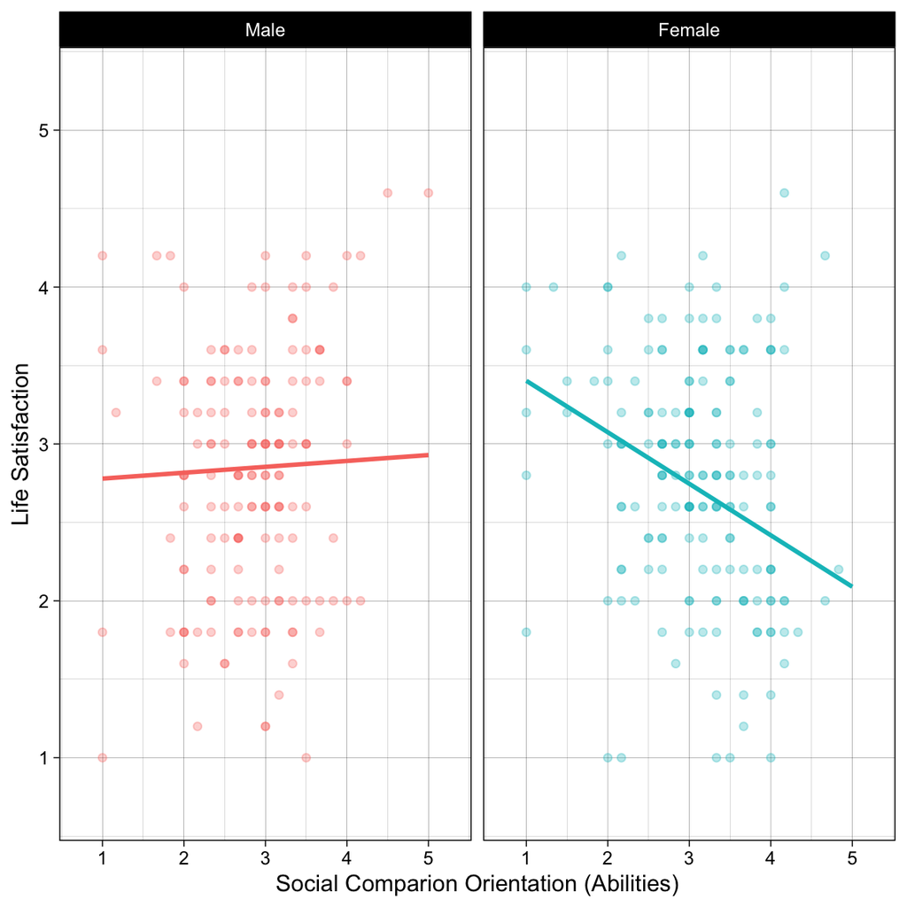

```r
ggplot(data, aes(x = sca, y = swl))+
  geom_point(aes(color = factor(fem)), alpha = 0.3)+
  geom_line(data = grid, aes(y = pred, color = factor(fem)), size = 1)+
  labs(x="Social Comparion Orientation (Abilities)",
       y="Life Satisfaction",
       color="Gender")+
  coord_cartesian(ylim=c(0.7, 5.3), xlim=c(0.7, 5.3))+
  facet_wrap(. ~ factor(fem),
             labeller=as_labeller(c("0"="Male","1"="Female")))+
  theme_linedraw() +
  theme(legend.position="none")
```

### Part 2: Comparison X Education

Unlike `gender`, which is a **categorical** variable, `education` is a **continuous variable** in our model. To make it easier for interpretation, we categorized them into three levels (`mean below 1SD`, `mean`, and `mean above 1SD`). We set gender at 0.5 instead of 0, as the ratio of male and female is equal.

```r
data2 %>% summarise(sd(educ))
```

```
## # A tibble: 1 × 1
##   `sd(educ)`
##        <dbl>
## 1       1.26
```

```r
grid_group3 <- data2 %>%
  data_grid(sca, educ = c(-1.26, 0.00, 1.26),
            fem = 0.5, ageyear = 0, income = 0, scb = 0) %>%
  add_predictions(model2)
```

We undid the centering of variable (`sca`).

```r
grid <- grid_group3 %>%
  mutate(sca = sca + mean(data$sca), educ = factor(as.double(factor(educ))))
```

The following figure represents the three lines that represent differing education levels set at `M-1SD`, `Mean`, `M+1SD`, as noted above, and how differing education levels make differences to relationships between social comparison orientation and life satisfaction.

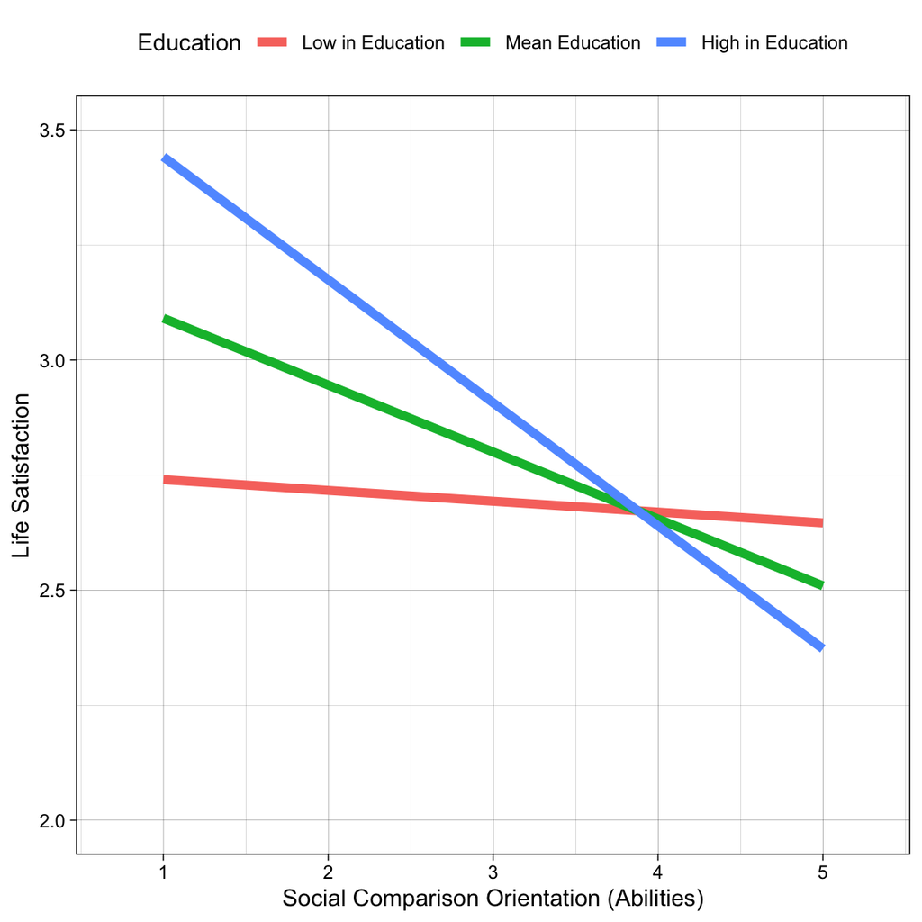

```r
ggplot(grid, aes(x = sca, y = pred, color = factor(educ))) +
  geom_line(size = 2) +
  scale_color_discrete(breaks = c(1, 2, 3),
                       label=c("Low in Education",
                               "Mean Education",
                               "High in Education")) +
  labs(x = "Social Comparison Orientation (Abilities)",
       y = "Life Satisfaction",
       color = "Education") +
  coord_cartesian(ylim = c(2.0, 3.5), xlim = c(0.7, 5.3)) +
  theme_linedraw() +
  theme(legend.position= "top")
```

## DO THIS WAY :)

> Prof. Roh’s Note: “Yes, you might want to perform the analysis above, using `jtools`, `huxtable`, `ggstance`, and `interactions` packages, as you have learned in class.”

```r
pacman::p_load(jtools, huxtable, ggstance, interactions)

m1 <- lm(swl ~ fem + ageyear + educ + income + sca + scb,
         data = data)

m2 <- lm(swl ~ (fem + ageyear + educ + income) * sca + scb,
         data = data)

export_summs(m1, m2,
             error_format = "(t = {statistic}, p = {p.value})",
             align = "right",
             model.names = c("Main Effects Only", "with Interactions"),
             digits = 3)
```

|  | Main Effects Only | with Interactions |
| --- | --- | --- |
| (Intercept) | 2.638 *** | 2.165 ** |
|  | (t = 10.117, p = 0.000) | (t = 3.154, p = 0.002) |
| fem | -0.067 | 0.989 ** |
|  | (t = -0.776, p = 0.438) | (t = 2.879, p = 0.004) |
| ageyear | -0.017 *** | -0.033 * |
|  | (t = -4.424, p = 0.000) | (t = -1.990, p = 0.047) |
| educ | 0.091 * | 0.375 * |
|  | (t = 2.467, p = 0.014) | (t = 2.572, p = 0.011) |
| income | 0.054 ** | -0.059 |
|  | (t = 2.944, p = 0.003) | (t = -0.767, p = 0.444) |
| sca | -0.206 ** | 0.021 |
|  | (t = -2.815, p = 0.005) | (t = 0.093, p = 0.926) |
| scb | 0.250 ** | 0.217 ** |
|  | (t = 3.194, p = 0.002) | (t = 2.819, p = 0.005) |
| fem:sca |  | -0.366 ** |
|  |  | (t = -3.208, p = 0.001) |
| ageyear:sca |  | 0.005 |
|  |  | (t = 0.921, p = 0.358) |
| educ:sca |  | -0.097 * |
|  |  | (t = -2.028, p = 0.043) |
| income:sca |  | 0.037 |
|  |  | (t = 1.480, p = 0.140) |
| N | 331 | 331 |
| R2 | 0.112 | 0.158 |
| *** p < 0.001; ** p < 0.01; * p < 0.05. |  |  |

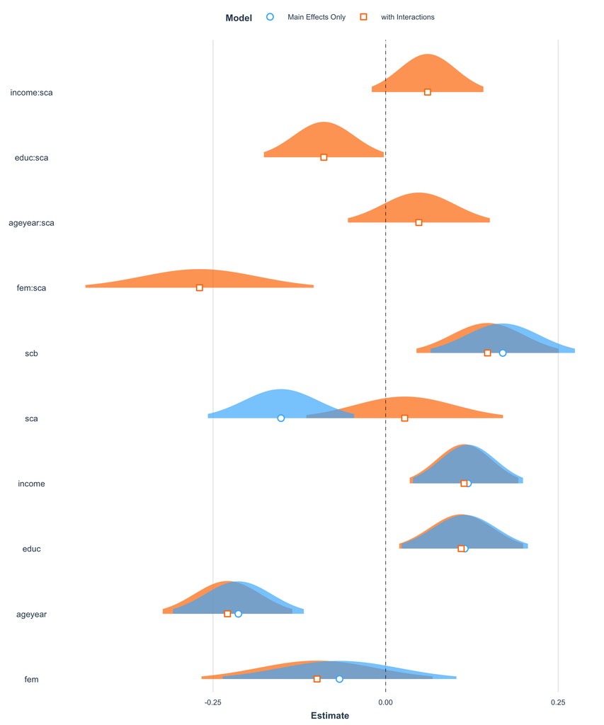

```r
plot_summs(m1, m2,
           scale = T,
           plot.distributions = T,
           model.names = c("Main Effects Only", "with Interactions")) +
  theme(legend.position = "top")
```

```r
sim_slopes(m2,
           pred = sca,
           modx = fem,
           johnson_neyman = F)
```

```
## SIMPLE SLOPES ANALYSIS
##
## Slope of sca when fem = 0.00 (0):
##
##   Est.   S.E.   t val.      p
## ------ ------ -------- ------
##   0.04   0.10     0.38   0.70
##
## Slope of sca when fem = 1.00 (1):
##
##    Est.   S.E.   t val.      p
## ------- ------ -------- ------
##   -0.33   0.09    -3.76   0.00
```

```r
sim_slopes(m2,
           pred = fem,
           modx = sca,
           johnson_neyman = T)
```

```
## JOHNSON-NEYMAN INTERVAL
##
## When sca is OUTSIDE the interval [1.96, 3.19], the slope of fem is p < .05.
##
## Note: The range of observed values of sca is [1.00, 5.00]
##
## SIMPLE SLOPES ANALYSIS
##
## Slope of fem when sca = 2.239478 (- 1 SD):
##
##   Est.   S.E.   t val.      p
## ------ ------ -------- ------
##   0.17   0.11     1.48   0.14
##
## Slope of fem when sca = 2.976334 (Mean):
##
##    Est.   S.E.   t val.      p
## ------- ------ -------- ------
##   -0.10   0.09    -1.17   0.24
##
## Slope of fem when sca = 3.713190 (+ 1 SD):
##
##    Est.   S.E.   t val.      p
## ------- ------ -------- ------
##   -0.37   0.12    -2.97   0.00
```

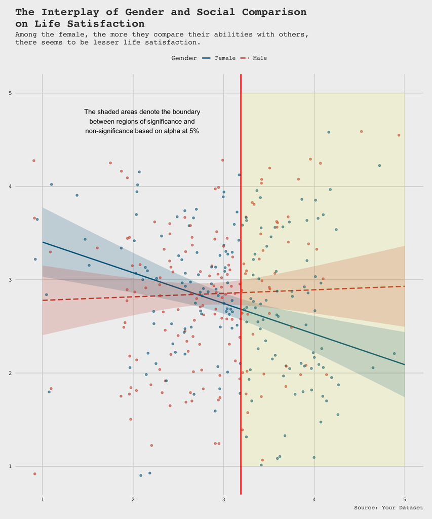

```r
set.seed(20210427)

interact_plot(m2,
              pred = "sca",
              modx = "fem",
              modx.labels = c("Male",
                              "Female"),
              interval = T,
              int.width = 0.95,
              colors = c("tomato3",
                         "deepskyblue4"),
              vary.lty = T,
              line.thickness = 1,
              legend.main = "Gender",
              plot.points = T,
              jitter = 0.1) +
  geom_vline(xintercept = 3.19, col = "red", linetype = 1, size = 1) +
  annotate("text",
           x = 2.1,
           y = 4.7,
           label = paste0("The shaded areas denote the boundary\nbetween regions ",
                          "of significance and\nnon-significance based on alpha at 5%")
           ) +
  annotate("rect",
           fill = "yellow",
           alpha = 0.1,
           xmin = 3.19,
           xmax = 5,
           ymin = 1,
           ymax = 5) +
  labs(title = "The Interplay of Gender and Social Comparison\non Life Satisfaction",
       subtitle = paste0("Among the female, the more they compare their abilities ",
                         "with others,\nthere seems to be lesser life satisfaction."),
       caption = "Source: Your Dataset",
       x = "Social Comparison of Abilities (1-5)",
       y = "Life Satisfaction (1-5)") +
  ggthemes::theme_fivethirtyeight() +
  theme(legend.position = "top",
        text = element_text(family = "Courier"),
        axis.text.y = element_text())
```

## Interpretation of the Results

From our data science project, we could find the following two findings:

1. The relationships between the tendency of people to compare themselves to others’ abilities and life satisfaction differ depending on one’s gender. Specifically, there appears to be no relationship between social comparisons orientation and life satisfaction among males. On the other hand, among females, the more they compare their abilities with others, there seems to be lesser life satisfaction. Thus, social comparison seems to be harmful for life satisfaction among females, whereas there seems to be no relationships between social comparisons and life satisfaction among males. (You might want to highlight that the relationships between social comparisons orientation and life satisfaction is based on observational study, leading to correlations, not causations, in `Limitations and Future Directions` section below).
2. The relationships between social comparison and life satisfaction also depends on one’s education level. It appears that, among those who received average and high levels of education, the greater the social comparison tendency, the lower the life satisfaction. Such a negative relationship between social comparison and life satisfaction was not found among those with relatively lower levels of education. Social comparison regarding one’s abilities can hurt one’s life satisfaction, when one receives average and above-average levels of education (again, acknowledge that the findings are correlational though, thus further investigation with a/b testing should follow).

## Implications

> Prof. Roh’s Note: “This is where you provide the significance of the findings. Unlike the other sections, where your goal is to describe the results that you found (**what the data told you**). This is where you chime in and proactively discuss the meaning of the results.”

## Limitations and Future Directions

> Prof. Roh’s Note: “Acknowledging limitations is not where you just provide a laundry list of what is missing and what should have done. Please take the responsibility of your analyses and inform your readers to understand what the results tell and don’t (or can’t) tell. More importantly, this is the section where you technically begin your next data science project, by highlighting what would be informative down the line to shed further light on what you have found here.”

## Contribution Statement

> Prof. Roh’s Note: “Please describe your individual contribution to the team’s project (**in detail**).”